# 通信原理

## 第一章

### 消息、信息、信号

- 消息 aka. message

  通信系统传输的对象。信息的载体。

  语音、图片、文字、符号等。
- 信息 aka. information

  消息中包含的有效内容。信息是消息的内涵，消息是信息的物理表现。

  天气情况（信息）可以用语音、文字（消息）表达。
- 信号 aka. signal

  消息的传输载体。

  天气情况（信息）可以用语音、文字、图片等形式（消息）呈现；语音、图片、文字（消息）都需要转化成电信号、声信号、光信号（信号）才能传输。

  电信号、声信号等。

### 通信系统的一般模型

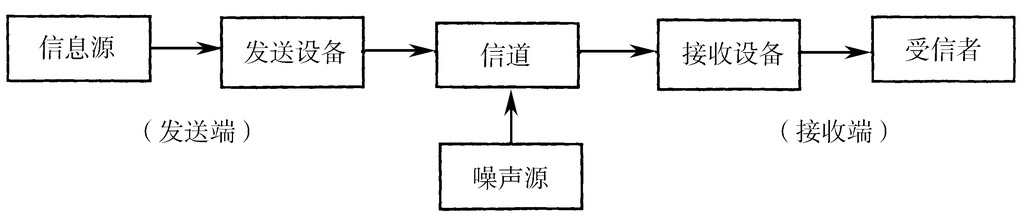

6元素

- 信源
- 发送设备
- 信道
- 噪声源
- 接收设备
- 信宿

### 模拟通信系统

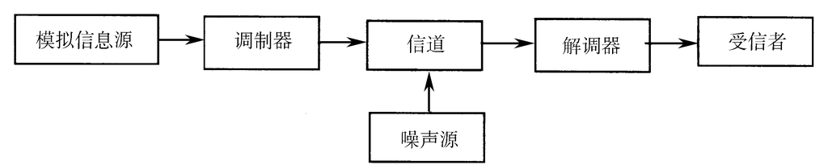

### 数字通信系统

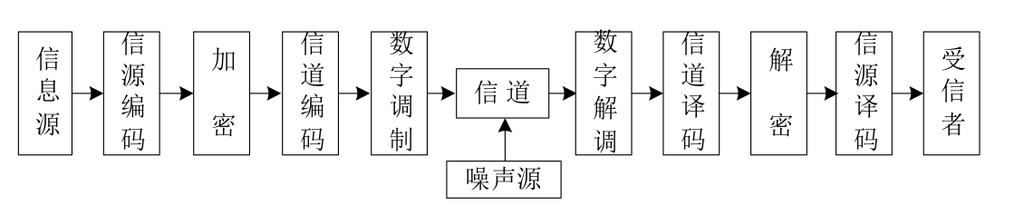

#### 数字通信系统的特点

优点

- 抗干扰，噪声不累积
- 传输差错可控
- 便于处理
- 便于集成
- 便于加密

缺点

- 传输带宽大
- 系统设备复杂

### 通信系统分类

按业务

- 电报
- 电话
- 数据
- 图像

按调制

- 基带
- 带通

按信号特征

- 数字
- 模拟

按传输媒介

- 有线
- 无线

按工作波段

- 长波
- 中波
- 短波
- 远红外

按信号复用方式

- 频分复用
- 时分复用
- 码分复用

### 通信方式

- 单工、半双工、全双工
- 并行、串行

### 消息的信息量

$$ I(x) = \log_2 {1 \over P(x)} \,({\rm bit}) $$

### 符号集的信息量期望 aka. 平均信息量

设一个符号集里有$N$个符号，每个符号出现的概率是$P(x_k)$。那么每个符号的信息量的期望是 $$ H = \sum_{k = 1}^N P(x_k) \log_2 {1 \over P(x_k)} \,({\rm bit / char}) $$

### 频带利用率

有效性。

\begin{align} \eta = {R_{\rm B} \over B} \,({\rm char / s / Hz}) \end{align}

或

\begin{align} \eta_b = {R_{\rm b} \over B} \,({\rm bit / s / Hz}) \end{align}

### 码元传输速率

每秒传送的**字符**的个数。记为$R_{\rm B}$。

### 信息传输速率

每秒传送的信息量。记为$R_{\rm b}$。

对于一个平均信息量为$H$的字符集来说，其中每个字符的信息量平均值都是$H$，所以有 $$ R_{\rm b} = R_{\rm B} H $$

如果符号集是$M$进制的，即符号集里总共有$M$个字符。因为$H = \log_2 M$，所以$R_{\rm b} = R_{\rm B} \log_2 M$。

### 误码率

\begin{align} P_{\rm e} = {错误码元个数 \over 传输码元总数} \end{align}

### 误信率

\begin{align} P_{\rm b} = {错误比特个数 \over 传输比特总数} \end{align}

## 第三章 随机过程

### 疑难

#### 书P61 3-5

设$s(t)$是一个平稳随机脉冲序列，其功率谱密度为$P_s(f)$，求已调信号$e(t) = s(t) \cos(\omega_c t)$的功率谱密度$P_e(f)$。

### 一些理解

随机变量和随机过程的一些对比。

\begin{align} & P(X \leq x) = F_X(x) &&\longleftrightarrow && P(\xi(t_1) \leq x_1) = F_{\xi(t_1)}(x_1) \\ & P(Y \leq y) = F_Y(y) &&\longleftrightarrow && P(\xi(t_2) \leq x_2) = F_{\xi(t_2)}(x_2) \\ & P(X \leq x \wedge Y \leq y) = F_{XY}(x, y) &&\longleftrightarrow && P(\xi(t_1) \leq x_1 \wedge \xi(t_2) \leq x_2) = F_{\xi(t_1) \xi(t_2)}(x_1, x_2) \end{align}

用下标记随机变量的概率密度、概率分布函数太麻烦了，因此定义 \begin{align} f_{\xi(t_1)}(x_1) &\doteq f(x_1 \color{red}{; t_1}) \\ F_{\xi(t_1)}(x_1) &\doteq F(x_1 \color{red}{; t_1}) \end{align}

\begin{align} & E[X] = \int_{-\infty}^{+\infty} x f_X(x) \,dx &&\longleftrightarrow && E[\xi(t_1)] = \int_{-\infty}^{+\infty} x_1 f_{\xi(t_2)}(x_1) \,dx_1 \\ & E[Y] = \int_{-\infty}^{+\infty} y f_Y(y) \,dy &&\longleftrightarrow && E[\xi(t_2)] = \int_{-\infty}^{+\infty} x_2 f_{\xi(t_2)}(x_2) \,dx_2 \\ & E[X Y] = \int_{-\infty}^{+\infty} \int_{-\infty}^{+\infty} x y f_X(x) f_Y(y) \,dx dy &&\longleftrightarrow && E[\xi(t_1) \xi(t_2)] = \int_{-\infty}^{+\infty} \int_{-\infty}^{+\infty} x_1 x_2 f_{\xi(t_1) \xi(t_2)}(x_1, x_2) \,dx_1 dx_2 \end{align}

从本质上来说，$\xi(t_1)$和$\xi(t_2)$就是两个**不同**的随机变量。它们可能相关可能不相关。

### 随机过程的一些特征

随机过程$\xi(t)$可以看做是：任意时刻$t$时的$\xi(t)$都是一个随机变量。

#### 期望

$$ E[\xi(t)] = \int_{-\infty}^{+\infty} x f(x; t) \,dx $$

常记为$a(t)$或$\mu(t)$。

$E[\xi(t)]$只定义为某个$t$时刻的信号的期望。不同$t$时刻的信号的期望可能不同。

#### 方差

\begin{align} D[\xi(t)] &= E\left[(\xi(t) - E[\xi(t)])^2\right] \\ &= E\left[\xi(t)^2\right] - E\left[\xi(t)\right]^2 \\ \end{align}

常记为$\sigma^2(t)$。

#### 自相关

\begin{align} R(t_1, t_2) &= E[\xi(t_1) \xi(t_2)] \\ &= \int_{-\infty}^{+\infty} \int_{-\infty}^{+\infty} x_1 x_2 f(x_1, x_2; t_1, t_2) \,dx_1 dx_2 \end{align}

#### 协方差

\begin{align} B(t_1, t_2) &= E[(\xi(t_1) - E[\xi(t_1)])(\xi(t_2) - E[\xi(t_2)])] \\ &= R(t_1, t_2) - E[\xi(t_1)] E[\xi(t_2)] \end{align}

因为协方差和自相关只相差一个常数，所以通常用自相关。

### 严平稳随机过程

如果随机过程和时间无关，也就是说对于任意$t$，$\xi(t)$服从完全相同概率分布 \begin{align} \forall i, j, x: \quad f_{\xi(t_i)}(x) = f_{\xi(t_j)}(x) \end{align} 注意，这里没有因为所有随机变量服从完全相同的概率分布，就说所有随机变量都互相**独立**。服从完全相同的概率分布**不等于**每个变量互相独立。

因为任意时刻随机变量都服从同一个概率分布了，所以自然所有的一维统计特征都随时间无关了、所有的二维统计特征都只和**时间间隔**有关而与**时刻**无关。

### 广义平稳随机过程

1. 期望$E[\xi(t)]$与$t$无关
2. 自相关$R(t_1, t_2)$与$t_1, t_2$具体取值无关、而只与$t_2 - t_1$有关

#### 验证某个随机过程是否是广义平稳过程

1. 算期望$E[\xi(t)]$，判断是否和$t$有关
2. 算自相关$R(t_1, t_2)$，判断是否只和$t_2 - t_1$有关

#### 各态历经性 aka. 遍历性

随机过程的任意一次**实现**（我觉得叫实例更好）都经历了随机过程的所有可能状态。因此统计特征可以由某次实例的**时间平均**（对$t$平均）代替统计平均（对$x$平均）。

#### 自相关函数的特性

\begin{align} R(\tau) = E[\xi(t) \xi(t + \tau)] \end{align}

1. $R(0) = E\left[\xi(t)^2\right]$。表示**平均**功率
2. $\lim_{\tau \to +\infty} R(\tau) = E[\xi(t)]^2$。表示**直流**功率
3. $\sigma^2 = R(0) - \lim_{\tau \to +\infty} R(\tau)$。表示方差

### Wiener-Khinchine关系

\begin{align} R(\tau) \mathop{\mathrel{\longleftrightarrow}}^{\cal F} P(f) \end{align}

### 高斯过程

## 第四章 信道

### 热噪声电压

热噪声电压有效值 \begin{align} V = \sqrt{4 k_B T R B} \end{align}

### 信道容量

有2种方式度量离散信道的容量

- 每个符号能传输的平均信息量 bit/char
- 单位时间内能传输的平均信息量 bit/s

这两种方式是等价的。中间只差一个码元传输速率。

每个符号能传输的平均信息量 \begin{align} C = H(X) - H(X | Y) \end{align}

单位时间内能传输的平均信息量 \begin{align} C_t = R_B [H(X) - H(X | Y)] \end{align}

> 书上的定义是$C = \max_{P(X)} [H(X) - H(X | Y)]$。我不懂这里的$\max$有什么意义，例题也没有用到。

我觉得有必要修正第一章里讲到的信息量的定义。因为这里出现了$H(X | Y)$。

定义随机变量$X$为发送的消息，$Y$为接收到的消息。这样样本空间$\Omega$是二维向量的集合 \begin{align} \Omega = \{&(x_1, y_1), (x_1, y_2), \ldots, (x_1, y_n), \\ &(x_2, y_1), (x_2, y_2), \ldots, (x_2, y_n), \\ &\phantom{(}\vdots \\ &(x_i, y_1), (x_i, y_2), \ldots, (x_i, y_n), \\ &\phantom{(}\vdots \\ &(x_n, y_1), (x_n, y_2), \ldots, (x_n, y_n) \} \end{align}

书中“发送码元$x_i$”的概率写作$P(x_i)$，严格来写应该是$P(X = x_i)$，更严格来写应该是$P(\{(x_k, y_l)| x_k = x_i\})$。

发送消息的信息量是每个发送码元的信息量的概率加权平均 \begin{align} H(X) = \sum_{x_i} P(X = x_i) \log_2 {1 \over P(X = x_i)} \end{align}

条件信息量是接收码元已知后、发送码元的平均信息量**对接收码元的概率的加权平均** \begin{align} H(X | Y) &= \underbrace{\sum_{y_j} P(Y = y_j)}_{接收码元概率的加权平均} \cdot \underbrace{\vphantom{\sum_{y_j}}H(X | Y = y_j)}_{接收码元已知后的平均信息量} \\ &= \sum_{y_j} P(Y = y_j) \sum_{x_i} P(X = x_i | Y = y_j) \log_2 {1 \over P(X = x_i | Y = y_j)} \end{align}

> 这个实在是太难理解了。

条件概率其实是很好算的，但是信道模型里线段上的概率是$P(Y = y_j | X = x_i)$的信息，而不是$P(X = x_i | Y = y_j)$。需要转换一下。由贝叶斯公式 \begin{align} P(X = x_i | Y = y_j) &= {P(X = x_i \land Y = y_j) \over P(Y = y_j)} \\ P(Y = y_j | X = x_i) &= {P(X = x_i \land Y = y_j) \over P(X = x_i)} \end{align} 所以 \begin{align} P(X = x_i | Y = y_j) = {P(Y = y_j | X = x_i) P(X = x_i) \over P(Y = y_j)} \end{align}

遇到计算信道容量的题，建议先写出每个条件的严格表达式，然后

1. 用 \begin{align} P(Y = y_j) = \sum_{x_i} P(Y = y_j | X = x_i) P(X = x_i) \end{align} 算出每个$P(Y = y_j)$。
2. 再算每个条件概率$P(X = x_i | Y = y_j)$。

## 第六章 数字基带传输系统

### 基带信号功率谱特性

分为

- 单极性、NRZ
- 单极性、RZ
- 双极性、NRZ
- 双极性、RZ

带宽

- NRZ带宽是$1 / T_{\rm B}$
- RZ带宽是$2 / T_{\rm B}$

定时分量

- 单极性NRZ没有定时分量，但可以提取
- 单极性RZ有定时分量
- 双极性没有定时分量，也不能提取

|  | 带宽 | 定时分量 |
| --- | --- | --- |
| 单极性NRZ | $f_{\rm B}$ | 可提取 |
| 单极性RZ | $2f_{\rm B}$ | 有 |
| 双极性NRZ | $f_{\rm B}$ | 无 |
| 双极性RZ | $2f_{\rm B}$ | 无 |

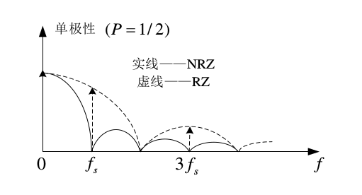

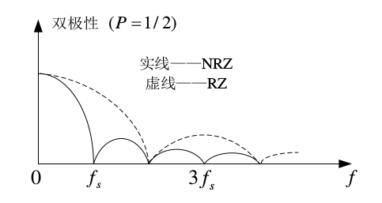

### 码型 vs. 波形

### 传输码型

#### AMI码

把消息中的1交替变换成+1和-1。0保持不变

比如

```
01110
0+-+0
```

优点

- 没有直流分量
- 高频、低频分量少
- 编码、译码电路简单

缺点

- 连续出现很多0的时候，无法提取定时信号

#### $\rm HDB_3$码

1. 标记出所有连续4个0的序列。这个叫**破坏节**。
2. 每个破坏节前面、直到上一个破坏节之后，如果出现偶数个1，此破坏节变成`B00V`；如果出现奇数个1，此破坏节变成`000V`。
3. 按AMI规则处理1。直到遇到某个破坏节。
4. 处理破坏节 如果破坏节是`B00V`
   - 前面的`1`变成了`+`，`B00V`变成`-00-`
   - 前面的`1`变成了`-`，`B00V`变成`+00+`

   如果破坏节是`000V`
   - 前面的`1`变成了`+`，`000V`变成`000+`
   - 前面的`1`变成了`-`，`000V`变成`000-`

例子

```
1000 0100 0011 0000 0000 11 base
 [   ] [   ]   [  ] [  ] 破坏节

+000 V
 [   ]
+000 +

+000 +-00 0V
       [   ]
+000 +-00 0-

+000 +-00 0-+- B00V
               [  ]
+000 +-00 0-+- +00+

+000 +-00 0-+- +00+ B00V
                    [  ]
+000 +-00 0-+- +00+ -00-

+000 +-00 0-+- +00+ -00- +- hdb3
1000 0100 0011 0000 0000 11 base
```

#### 双相码 aka. 曼彻斯特码 aka. biphase code

把0变成-+，1变成+-。

> 为什么明明是双极性，却用01。

比如

```
1 1 0 0
+-+--+-+
```

优点

- 定时信息丰富
- 编码简单
- 没有直流分量

缺点

- 带宽加倍

> 没有理解极性反转是什么意思

#### 差分双相码 aka. 差分曼彻斯特码 aka. differential biphase code

每个码元**开始**的地方，有跳变表示1，无跳变表示0。

#### 密勒码 aka. Miller code

简而言之就是看双相码，遇到一个下降沿就翻转一次。

把**双相码**接入T触发器的**下降沿**时钟端就可以得到密勒码。

#### CMI码 aka. 传号反转码 aka. coded mark inversion

0用01表示。1交替用11、00表示（无关紧邻还是不紧邻）。

#### nBmB码

把n个二进制码变成另一组m个二进制码。

双相码、密勒码、CMI码都可以看做1B2B码。

优点

- 同步
- 检错

缺点

- 带宽增大

#### nBmT码

把n个二进制码变成另一组m个三进制码。

### 码间串扰

无码间串扰的时域条件 \begin{align} h(k T_s) = \left\{\begin{aligned} &C \neq 0 &&\qquad, k = 0 \\ &0 &&\qquad, k \neq 0 \end{aligned}\right. \end{align}

无码间串扰的频域条件 aka. 奈奎斯特第一准则 \begin{align} \forall |f| \leq {1 \over 2 T_s}: \qquad \sum_{k = -\infty}^{\infty} H\left[j 2 \pi\left(f + {k \over T_s}\right)\right] = C \end{align}

相当于，把$H(j 2 \pi f)$以$\left({k \over T_s} - {1 \over 2 T_s}, {k \over T_s} + {1 \over 2 T_s}\right)$区间分开，并且都搬移到$\left(- {1 \over 2 T_s}, {1 \over 2 T_s}\right)$、叠加，应当是一个常数。

#### 奈奎斯特速率

系统无码间串扰的最高传输速率${1 \over T_s}$。

其实如果$T_s$是能保证系统无码间串扰的最小采样间隔，那么对于任意正整数$n$，以$n T_s$间隔传输**都不会**有码间串扰。相当于隔了几个零点采样。

#### 奈奎斯特带宽

系统无码间串扰的最高传输速率的一般${1 \over 2 T_s}$。

### 基带系统误码率

#### 二进制双极性

误码率 \begin{align} P_e = {1 \over 2} \operatorname{erfc}\left(A \over \sqrt{2} \sigma_n\right) \end{align}

最佳判决电平 \begin{align} V_d = {\sigma_n^2 \over 2 A} \ln {P(0) \over P(1)} \end{align}

信噪比？ \begin{align} {\rm SNR} = {A^2 \over \sigma_n^2} \end{align}

#### 二进制单极性

误码率 \begin{align} P_e = {1 \over 2} \operatorname{erfc}\left(A \over 2 \sqrt{2} \sigma_n\right) \end{align}

最佳判决电平 \begin{align} V_d = {A \over 2} + {\sigma_n^2 \over A} \ln {P(0) \over P(1)} \end{align}

信噪比？ \begin{align} {\rm SNR} = {A^2 \over 2 \sigma_n^2} \end{align}

### 部分响应

#### 相关编码

假设现在你有一串数据$\{ a_k \}$

```
1011 0001 011 a_k
```

现在要做相关编码。

1. 做**预编码**

   令 \begin{align} & b_k = a_k \oplus b_{k-1} \\ & b_0 = 0 \end{align}

   ```
   _ 1011 0001 011 a_k
   0 1101 1110 010 b_k
   ```

2. 做**相关编码**

   令 \begin{align} & C_k = b_k + b_{k-1} \end{align}

   ```
   _ 1011 0001 011 a_k
   0 1101 1110 010 b_k
   _ 1211 2221 011 C_k
   ```

   就可以发送出去了。
3. 接收端

   令 \begin{align} a_k' = C_k' \bmod 2 \end{align} 就是除以2取余数。

   ```
   _ 1011 0001 011 a_k
   0 1101 1110 010 b_k
   _ 1211 2221 011 C_k

   _ 1211 2221 011 C_k'
   _ 1011 0001 011 a_k'
   ```

## 第七章 数字带通传输系统

数字调制的两种方法

- 模拟调制

  把数字信号看成普通的模拟信号。模拟信号该怎么调制数字信号也怎么调制。
- 开关键控

  充分利用数字信号的离散特点，用开关控制载波。

### 2ASK

#### 调制

调制后信号 \begin{align} e(t) = s(t) \cos (2 \pi f_c t) \end{align} 其中$s(t) \in \{0, 1\}$是单极性、NRZ基带逻辑信号。

功率谱密度 \begin{align} P(f) = {1 \over 4} \left[P_s(f - f_c) + P_s(f + f_c)\right] \end{align} 其中$P_s(f)$是基带逻辑信号的功率谱密度。相当于把$P_s(f)$复制平移到了$\pm f_c$上。卷积原理。

主瓣带宽 \begin{align} B = 2 f_s = {2 \over T_s} \end{align} 取决于$s(t)$的功率谱。

#### 解调

- 非相干 aka. 包络检波法

  \begin{align} 全波整流（取绝对值) \to 低通滤波 \to 抽样判决 \end{align}
- 相干 aka. 同步检测法

  用类似模拟信号解调的方法。

  \begin{align} 乘载波信号 \to 低通滤波 \to 抽样判决 \end{align}

#### 误码率

与解调方式有关

- 非相干

### 2FSK

#### 调制

开关键控法调制后信号 \begin{align} e(t) = \underbrace{s(t)}_{s_1(t)} \cos(2 \pi f_1 t + \phi_1) + \underbrace{[1 - s(t)]}_{s_2(t)} \cos(2 \pi f_2 t + \phi_2) \end{align} 要注意开关键控法调制的信号，相位不一定连续。而模拟调频法产生的是相位连续的信号。

功率谱 \begin{align} P(f) &= \overbrace{{1 \over 4} [P_{s1}(f - f_1) + P_{s1}(f + f_1)]}^{s(t)\cos(2 \pi f_1 t + \phi_1) 的功率谱} \\ &\phantom{=}+ \underbrace{{1 \over 4} [P_{s2}(f - f_2) + P_{s2}(f + f_2)]}_{[1 - s(t)] \cos(2 \pi f_2 t + \phi_2)的功率谱} \end{align} 因为2FSK调制信号可以看做是两个载波信号不同的2ASK调制信号的叠加。根据傅里叶变换的线性性质，功率谱当然也可以看做两个信号的功率谱的叠加。

主瓣带宽 \begin{align} B \approx |f_2 - f_1| + 2 f_s \end{align}

#### 解调

- 非相干
- 相干

  用类似模拟信号的解调方法。

### 2PSK

用**绝对相位**表示二进制逻辑。

#### 调制

调制后信号 \begin{align} e(t) = [2 s(t) - 1] \cos(2 \pi f_c t) \end{align}

> 这里明显用$2 s(t) - 1$更方便，不知道为什么非要混淆定义、让$s(t)$又去代表一个双极性逻辑信号。

功率谱密度 \begin{align} P(f) = {1 \over 4} [P_{2s-1}(f - f_c) + P_{2s-1}(f + f_c)] \end{align}

主瓣带宽 \begin{align} B = 2 f_s = {2 \over T_s} \end{align} 和2ASK一样。

### 2DPSK

用**相位是否跳变**表示二进制逻辑。

主瓣带宽 \begin{align} B = 2 f_s = {2 \over T_s} \end{align} 和2PSK一样。

#### 解调

- 相干解调

解调的方法比2PSK的解调方法只多一个步骤。就是在得到相对码之后，再转为绝对码。 \begin{align} 乘载波 \to 低通滤波 \to 抽样判决 \color{red}{\mathop{\to}^{相对码} 码反变换} \end{align}

- 差分相干解调 aka. 相位比较法

\begin{align} 乘延迟了一个抽样间隔的自身 \to 低通滤波 \to 抽样判决 \end{align}

[figure not shown]

### MASK

带宽 \begin{align} B = \max_{i \neq j} |f_i - f_j| + f_s \end{align}

### MFSK

### MPSK

### MDPSK

### MSK aka. 最小频移键控

## 第九章

### 模拟信号数字化

1. 采样
2. 量化
3. 编码

### 抽样定理

\begin{align} f_s > 2 f_\max \end{align}

### 均匀量化

模拟信号的范围是$[a, b]$，量化电平数量是$M$个。这样均匀量化间隔是 \begin{align} \Delta v = {b - a \over M} \end{align}

量化区间的端点是 \begin{align} m_i = a + i \Delta v, \qquad i \in \{0, 1, \ldots, M\} \end{align} 第$i$个量化区间的范围是 \begin{align} [m_{i-1}, m_i], \qquad i \in \{1, \ldots, M\} \end{align}

第$i$个量化输出电平是 \begin{align} q_i \in (m_{i-1}, m_i) \end{align} 如果取每个量化间隔区间的中点，那么 \begin{align} q_i = {m_{i-1} + m_i \over 2} = a + \left(i - {1 \over 2}\right) \Delta v \end{align}

#### 均匀量化噪声

量化一定会带来噪声，因为抽样值不再连续。

假设量化电平数量是$M$个，模拟信号范围是$[a, b]$。设抽样信号随机变量是$S$，那么量化信号$m_q(S)$是$S$的分段函数 \begin{align} m_q(S) = \left\{\begin{aligned} & q_1, &&\qquad a \leq S < a + \Delta v \\ & q_2, &&\qquad a + \Delta v \leq S < a + 2 \Delta v \\ & \vdots &&\qquad \vdots \\ & q_i, &&\qquad a + (i - 1) \Delta v \leq S < a + i \Delta v \\ & \vdots &&\qquad \vdots \\ & q_M, &&\qquad b - \Delta v \leq S \leq b \end{aligned}\right. \end{align} 所以量化噪声功率是 \begin{align} N_q &= E\left[(S - m_q(S))^2\right] \\ &= \int_a^b (s - m_q(s))^2 f_S(s) \,ds \\ &= \sum_{i=1}^M \int_{m_{i-1}}^{m_i} (s - q_i)^2 f_S(s) \,ds \end{align} $f_S(s)$是抽样信号的概率密度函数。

> **特例** 如果量化输出电平正好是每个量化间隔区间的中点、输入信号在$[a, b]$之间均匀分布，那么上面的式子变成 \begin{align} P_n &= \sum_{i=1}^M \int_{a + (i - 1) \Delta v}^{a + i \Delta v} (s - q_i)^2 {1 \over b - a} \,ds \\ &= \sum_{i=1}^M {(\Delta v)^3 \over 12 (b - a)} \\ &= {M \over 12 (b - a)} (\Delta v)^3 \\ &= {1 \over 12} \left({b - a \over M}\right)^2 \end{align}

信号功率 \begin{align} P_s &= E[S^2] \\ &= \int_a^b s^2 f_S(s) ds \end{align}

> **特例** 如果输入信号在$[a, b]$之间均匀分布，那么信号功率变成 \begin{align} P_s = {1 \over 3} \cdot {b^3 - a^3 \over b - a} \end{align}

> 信噪比为 \begin{align} {P_s \over P_n} = {b^3 - a^3 \over (b - a)^3} \cdot 4 M^2 \end{align}

### 非均匀量化

均匀量化的问题

- 一般情况下信号幅度不会太大
- 信号小时，信号信噪比太小

为了保持信号小时信噪比恒定，需要非均匀量化。理论上 \begin{align} y = 1 + {1 \over k} \ln x \end{align} 但是这个关系不符合因果律。

#### A律

\begin{align} y = \left\{\begin{aligned} & {A x \over 1 + \ln A}, &&\qquad 0 < x \leq {1 \over A} \\ & {1 + \ln (A x) \over 1 + \ln A}, &&\qquad {1 \over A} \leq x \leq 1 \end{aligned}\right. \end{align} $A$通常选择为87.6。目的是

- 原点附近斜率近似等于16
- 折线端点上的横坐标近似等于2的负次方

A律通常配合13折线法实现。一共13条斜率不同的折线、14个端点。

其实本来应该有16条折线，但是其中有4条折线斜率相同，它们合并为1条折线。这4条折线是原点紧邻的四条折线。

仅看第一象限，有8段、9个端点、7个斜率

- (0, 0)
- (1/128, 1/8)
- (1/64, 2/8)
- (1/32, 3/8)
- (1/16, 4/8)
- (1/8, 5/8)
- (1/4, 6/8)
- (1/2, 7/8)
- (1, 1)

#### $\mu$律

如果不考虑使原点附近斜率近似为16，可以让折线端点横坐标更近似等于2的负次方 \begin{align} y = {\ln(1 + \mu x) \over \ln(1 + \mu)} \end{align} 并配合15折线律。一共15条斜率不同的折线、16个端点

同样，其实本来应该有16条，但是其中2条穿过原点的折线斜率相同，所以合并成1条。

仅看第一象限，有8段、9个端点、8个斜率

- (0, 0)
- (1/255, 1/8)
- (3/255, 2/8)
- (7/255, 3/8)
- (15/255, 4/8)
- (31/255, 5/8)
- (63/255, 6/8)
- (127/255, 7/8)
- (1, 1)

除了(0, 0)和(1, 1)之外的其他点可以概括成 \begin{align} \left({2^i - 1 \over 255}, {i \over 8}\right), \qquad i \in \{0, 1, \ldots, 7, 8\} \end{align}

### 编码

8位码推导方法 \begin{align} \underbrace{C_1}_{极性码} \,\underbrace{C_2 C_3 C_4}_{段码} \,\underbrace{C_5 C_6 C_7 C_8}_{段内码} \end{align}

- 极性码

  用来标记正负。

  正 = 1

  负 = 0
- 段码

  用来标记是属于哪段折线。

  很简单，看那个电压在哪段折线里。

  比如0.62，因为$1 / 2 < 0.62 < 1$，所以在第7段（倒数第一段）里。所以$C_2 C_3 C_4 = 7 = 111_2$

  > 这里的段**从0开始数**比较方便，只要直接转换成二进制就是段码了。
- 段内码

  用来标记属于这段折线上的16个量化间隔里的哪个间隔。

  很简单，逐次比较，比较4次就可以。或者如果能一眼看出也可以。

  比如0.62
  1. 看在0-7间隔还是8-15间隔

     因为$1 / 2 < 0.62 < 3 / 4$，在0-7间隔，所以$C_5 = 0$。
  2. 看在0-3间隔还是4-7间隔

     因为$1 / 2 < 0.62 < 5 / 8$，在0-3间隔，所以$C_6 = 0$。
  3. 看在0-1间隔还是2-3间隔

     因为$9 / 16 < 0.62 < 5 / 8$，在2-3间隔，所以$C_7 = 1$。
  4. 看在2还是3间隔

     因为$19 / 32 < 0.62 < 5 / 8$，在3间隔，所以$C_8 = 1$。

  所以$C_5 C_6 C_7 C_8 = 0011_2$。

最终$C_1 C_2 C_3 C_4 C_5 C_6 C_7 C_8 = 1111\,0011_2$。

### 时分复用 aka. TDM

- 时隙

  时间片。
- 帧

  一轮时间片。帧的长度就是两次回到同一个时间片之间的时间间隔。

### 例题

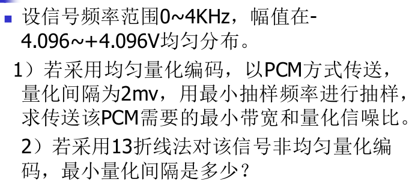

由奈奎斯特率 \begin{align} f_s > 2 f_\max = 8 \,{\rm kHz} \end{align} 所以最小采样频率是$8 \,{\rm kHz}$。

量化间隔$\Delta v = 0.002$，输入信号范围是$[-4.096, +4.096]$。所以量化电平个数是 \begin{align} M = {b - a \over \Delta v} = {4.096 + 4.096 \over 0.002} = 4096 = 2^{12} \end{align} 所以每个样本的比特数是12。

如果要保证采样、传送同步进行，那么每个比特的持续时间是 \begin{align} T_b = {T_s \over 12} = {1 \over 12 f_s} \end{align} 即比特率是 \begin{align} R_b = {1 \over T_b} = 12 f_s \end{align}

> 如果是12进制码组，那么每个码元持续时间可以和采样间隔一样

> \begin{align} T_B = T_s = {1 \over f_s} \end{align}

如果用最节省带宽的**二进制NRZ基带信号传输系统**，需要带宽 \begin{align} B = R_b = 12 f_s = 96 \,{\rm kHz} \end{align}

> 但是如果是**12进制NRZ基带传输系统**，那么带宽更低，就是$f_s$了。

> 此处存疑

最小量化间隔 \begin{align} 4.096 \cdot \underbrace{1 \over 128}_{段} \cdot \underbrace{1 \over 16}_{段内} = 0.002 \end{align}

段间量化间隔最小的是第1、2段，只有$1 / 128$。而且再配合段内16级量化，那么最小量化间隔就是幅值的$1 / 2048$。

## 第十章 数字信号的最佳接收

**最佳**的准则

- 最小差错概率

  相关接收
- 最大输出信噪比

  匹配接收

### 确知信号的最佳接收

以二进制为例，如果 \begin{align} W_1 + \int_0^{T_B} r(t) s_1(t) \,dt < W_0 + \int_0^{T_B} r(t) s_0(t) \,dt \end{align} 就判定发送的是$s_0(t)$。反之就是$s_1(t)$。

其中 \begin{align} W_0 &= {n_0 \over 2} \ln P(0) \\ W_1 &= {n_0 \over 2} \ln P(1) \end{align} $P(0), P(1)$是发送0或1的先验概率。

这样接收机的框图也很容易出来。接收信号进来分成两路。上路乘$s_0(t)$、积分、加$W_0$；下路乘$s_1(t)$、积分、加$W_1$。两路信号再经过判决器，按照上面的不等式来判定是0还是1。

如果先验概率相等，那么都不用分别加$W_0, W_1$了。

#### 最小误码率

码元能量 \begin{align} E_0 &= \int_0^{T_B} |s_0(t)|^2 \,dt \\ E_1 &= \int_0^{T_B} |s_1(t)|^2 \,dt \end{align} 如果$E_0 = E_1$，那么记$E_b = E_0 = E_1$。

相关系数 \begin{align} \rho &= {\langle s_0(t), s_1(t) \rangle \over \sqrt{\langle s_0(t), s_0(t)\rangle \cdot \langle s_1(t), s_1(t) \rangle}} \\ &= {\int_0^{T_B} s_0(t) s_1(t) \,dt \over \sqrt{E_0 E_1}} \end{align}

> $s_0(t) = s_1(t)$时，$\rho = 1$，最大。

> $s_0(t) = - s_1(t)$时，$\rho = -1$，最小。

> 2FSK的时候还会出现$\rho = 0$，此时称为**正交**。

误码率 \begin{align} P_e = {1 \over 2} \operatorname{erfc} \sqrt{E_b (1 - \rho) \over 2 n_0} \end{align}

### 匹配滤波接收

匹配滤波器的单位冲激响应 \begin{align} h(t) = s(T_s - t) \end{align}

传输函数 \begin{align} H(j 2 \pi f) = S^*(f) \cdot e^{- j 2 \pi f T_s} \end{align}

接收机框图就是接收信号分为上下两路。上路经过$h_0(t)$滤波器，下路经过$h_1(t)$滤波器。两路合并做判决。

## 第十三章 同步原理

- 载波同步

  为了在接收机端产生一个和接收信号的载波同频率、同相位的本地振荡信号。用于相干解调。
- 码元同步 aka. 位同步

  得知每个码元的起止时间，作判决。
- 群同步 aka. 帧同步

  为了将接收码元正确分组。

  e.g. 我们知道ascii每个字符都是7个bit，但是当一串bit传过来的时候，我们怎么才能知道从哪里开始算这7个bit呢？

  e.g. 一张图片有很多byte，但是图片需要在知道长、宽的情况下才能显示出来。
- 网同步

  为了使通信网络中每个站点的时钟保持同步。

### 载波同步

根据信号里有没有额外的用于**提示**接收机产生载波频率振荡的信息，区别对待。如果

- 有辅助导频

  在接收端用窄带通滤波器过滤出载波频率。
- 无辅助导频

  例如先验概率相等的2PSK信号里没有离散频率分量。

  可以用非线性的方法获得载波频率。
  - 平方环
  - 科斯塔斯环

#### 平方环

以先验概率相等的2PSK信号为例 \begin{align} e(t) = s(t) \cos(2 \pi f_c t) \end{align} 如果在接收端平方 \begin{align} e(t)^2 &= s(t)^2 \cos^2 (2 \pi f_c t) \\ &= {1 \over 2} [1 + \cos (2 \cdot 2 \pi f_c t)] \end{align} 含有$2 f_c$频率分量。

\begin{align} 平方 \to 锁相 \to 2分频 \end{align}

#### 科斯塔斯环 aka. 同相正交环 aka. 边环

平方环的问题

- 平方后，频率加倍，锁相环、2分频电路的工作频率加倍，实现难度加大

### 码元同步 aka. 位同步

- 外同步 aka. 插入导频法

  需要在信号中另外加入包含码元定时信息的导频或者数据序列。
- 自同步 aka. 直接法

  不需要辅助同步信息。
  - 开环同步法
  - 闭环同步法

### 群同步

### 网同步